# IEU GWAS QC Report

## IEU GWAS information

Trait: **Estimated glomerular filtration rate**.

| name | value |
| --- | --- |
| author | Howe LJ |
| consortium | Within family GWAS consortium |
| subcategory | NA |
| category | NA |
| build | HG19/GRCh37 |
| population | European |
| trait | Estimated glomerular filtration rate |
| sex | Males and Females |
| group_name | public |
| year | 2022 |
| nsnp | 7892788 |
| unit | mL/minute |
| id | ieu-b-4832 |
| ontology | EFO:0005208 |
| note | Population estimate |
| sample_size | 76511 |

## Report information

| name | value |
| --- | --- |
| gwas_id | ieu-b-4832 |
| bcf_file | ieu-b-4832.vcf.gz |
| qc_metrics_file | qc_metrics.json |
| metadata | metadata.json |
| refdata | 1kg_v3_nomult.bcf |
| compile_time | 2022-01-05 10:13 UTC |
| build_version | master-74213fc-2021-03-26 |

# Summary

## Summary {data-width=650}

### Manhattan plot

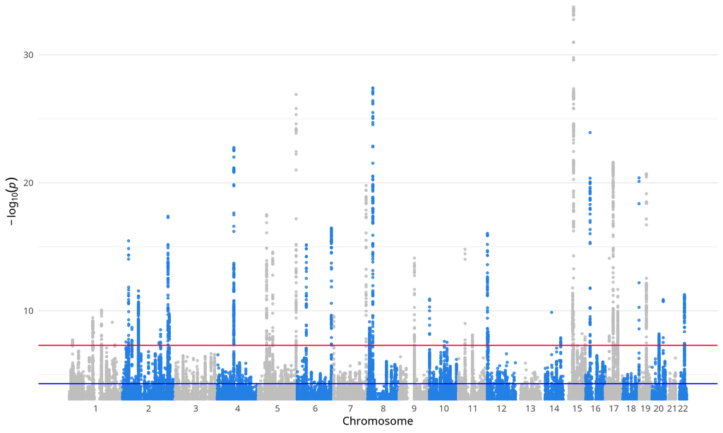

manhattan_plot

### QQ plot

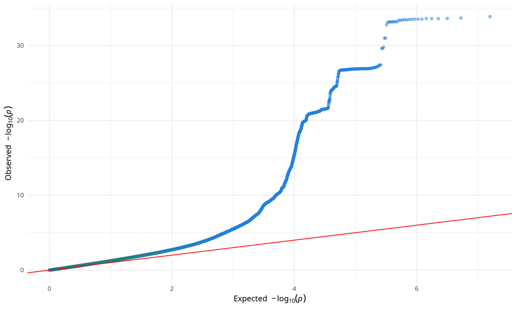

qq_plot

### AF plot

[figure not shown]

af_plot

### P-Z plot

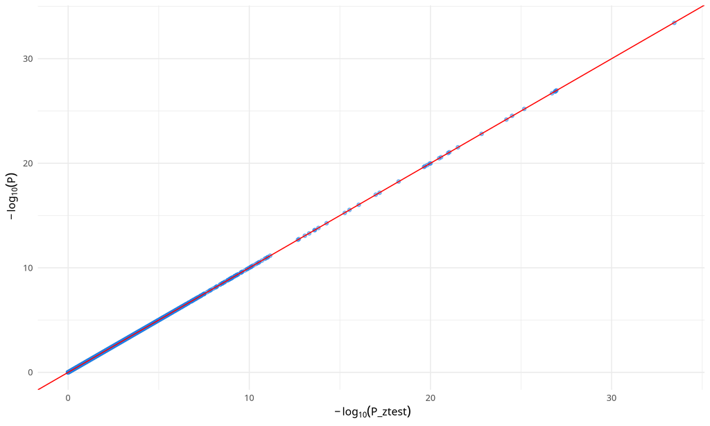

pz_plot

### beta_std plot

[figure not shown]

beta_std_plot

### Metadata

[output not shown]

### LDSC

```
*********************************************************************
* LD Score Regression (LDSC)
* Version 1.0.1
* (C) 2014-2019 Brendan Bulik-Sullivan and Hilary Finucane
* Broad Institute of MIT and Harvard / MIT Department of Mathematics
* GNU General Public License v3
*********************************************************************
Call:
./ldsc.py \
--h2 /data/cromwell-executions/qc/215c1327-7aef-468d-ae36-ab303651184e/call-ldsc/inputs/-261044479/ieu-b-4832.vcf.gz \
--ref-ld-chr /data/ref/eur_w_ld_chr/ \
--out /data/igd/ieu-b-4832/ldsc.txt \
--w-ld-chr /data/ref/eur_w_ld_chr/

Beginning analysis at Wed Jan  5 09:59:06 2022
Reading summary statistics from /data/cromwell-executions/qc/215c1327-7aef-468d-ae36-ab303651184e/call-ldsc/inputs/-261044479/ieu-b-4832.vcf.gz ...
Read summary statistics for 7892730 SNPs.
Dropped 38590 SNPs with duplicated rs numbers.
Reading reference panel LD Score from /data/ref/eur_w_ld_chr/[1-22] ... (ldscore_fromlist)
Read reference panel LD Scores for 1290028 SNPs.
Removing partitioned LD Scores with zero variance.
Reading regression weight LD Score from /data/ref/eur_w_ld_chr/[1-22] ... (ldscore_fromlist)
Read regression weight LD Scores for 1290028 SNPs.
After merging with reference panel LD, 1196616 SNPs remain.
After merging with regression SNP LD, 1196616 SNPs remain.
Using two-step estimator with cutoff at 30.
Total Observed scale h2: 0.1701 (0.0146)
Lambda GC: 1.3239
Mean Chi^2: 1.4158
Intercept: 1.1489 (0.0099)
Ratio: 0.3581 (0.0239)
Analysis finished at Wed Jan  5 10:00:56 2022
Total time elapsed: 1.0m:49.77s
```

# QC metrics

## Metrics

### Metrics

```
{
    "af_correlation": "NA",
    "inflation_factor": 1.2998,
    "mean_EFFECT": -0.0002,
    "n": 76511,
    "n_snps": 7892788,
    "n_clumped_hits": 47,
    "n_p_sig": 3403,
    "n_mono": 0,
    "n_ns": 285919,
    "n_mac": 0,
    "is_snpid_unique": false,
    "n_miss_EFFECT": 0,
    "n_miss_SE": 0,
    "n_miss_PVAL": 0,
    "n_miss_AF": 7892788,
    "n_miss_AF_reference": 161488,
    "n_est": "NA",
    "ratio_se_n": "NA",
    "mean_diff": "NaN",
    "ratio_diff": "NaN",
    "sd_y_est1": "NaN",
    "sd_y_est2": "NA",
    "r2_sum1": 0,
    "r2_sum2": 0,
    "r2_sum3": 0,
    "r2_sum4": 0,
    "ldsc_nsnp_merge_refpanel_ld": 1196616,
    "ldsc_nsnp_merge_regression_ld": 1196616,
    "ldsc_observed_scale_h2_beta": 0.1701,
    "ldsc_observed_scale_h2_se": 0.0146,
    "ldsc_intercept_beta": 1.1489,
    "ldsc_intercept_se": 0.0099,
    "ldsc_lambda_gc": 1.3239,
    "ldsc_mean_chisq": 1.4158,
    "ldsc_ratio": 0.3581
}
```

### Flags

| name | value |
| --- | --- |
| af_correlation | NA |
| inflation_factor | TRUE |
| n | FALSE |
| is_snpid_non_unique | TRUE |
| mean_EFFECT_nonfinite | FALSE |
| mean_EFFECT_05 | FALSE |
| mean_EFFECT_01 | FALSE |
| mean_chisq | TRUE |
| n_p_sig | TRUE |
| miss_EFFECT | FALSE |
| miss_SE | FALSE |
| miss_PVAL | FALSE |
| ldsc_ratio | FALSE |
| ldsc_intercept_beta | FALSE |
| n_clumped_hits | FALSE |
| r2_sum1 | FALSE |
| r2_sum2 | FALSE |
| r2_sum3 | FALSE |
| r2_sum4 | FALSE |

### Definitions

**General metrics**

- `af_correlation`: Correlation coefficient between `AF` and `AF_reference`.
- `inflation_factor` (`lambda`): Genomic inflation factor.
- `mean_EFFECT`: Mean of `EFFECT` size.
- `n`: Maximum value of reported sample size across all SNPs, $n$.
- `n_clumped_hits`: Number of clumped hits.
- `n_snps`: Number of SNPs
- `n_p_sig`: Number of SNPs with pvalue below `5e-8`.
- `n_mono`: Number of monomorphic (`MAF == 1` or `MAF == 0`) SNPs.
- `n_ns`: Number of SNPs with nonsense values:
  - alleles other than `A, C, G or T`.
  - P-values `< 0` or `> 1`.
  - negative or infinite standard errors (`<= 0` or `= Infinity`).
  - infinite beta estimates or allele frequencies `< 0` or `> 1`.
- `n_mac`: Number of cases where `MAC` ($2 \times N \times MAF$) is less than `6`.
- `is_snpid_unique`: `true` if the combination of `ID` `REF` `ALT` is unique and therefore no duplication in snpid.
- `n_miss_<*>`: Number of `NA` observations for `<*>` column.

**se_n metrics**

- `n_est`: Estimated sample size value, $\widehat{n}$.
- `ratio_se_n`: $\texttt{ratio_se_n} = \frac{\sqrt{\widehat{n}}}{\sqrt{n}}$. We expect `ratio_se_n` to be 1. When it is not 1, it implies that the trait did not have a variance of 1, the reported sample size is wrong, or that the SNP-level effective sample sizes differ markedly from the reported sample size.
- `mean_diff`: $\texttt{mean_diff} = \sum_{j} \frac{\widehat{\beta_j^{std}} - \beta_j}{\texttt{n_snps}}$, mean difference between the standardised beta, predicted from P-values, and the observed beta. The difference should be very close to zero if trait has a variance of 1.
  - $\widehat{\beta_j^{std}} = \sqrt{\frac{{z}_j^2 / ({z}_j^2 + n -2)}{2 \times {MAF}_j \times (1 - {MAF}_j)}} \times sign({z}_j)$,
  - ${z}_j = \frac{\beta_j}{{se}_j}$,
  - and $\beta_j$ is the reported effect size.
- `ratio_diff`: $\texttt{ratio_diff} = |\frac{\texttt{mean_diff}}{\texttt{mean_diff2}}|$, absolute ratio between the mean of `diff` and the mean of `diff2` (expected difference between the standardised beta predicted from P-values, and the standardised beta derived from the observed beta divided by the predicted SD; **NOT** reported). The ratio should be close to 1. If different from 1, then implies that the betas are not in a standard deviation scale.
  - $\texttt{mean_diff2} = \sum_{j} \frac{\widehat{\beta_j^{std}} - \beta^{\prime}_j}{\texttt{n_snps}}$
  - $\beta^{\prime}_j = \frac{\beta_j}{\widehat{\texttt{sd2}}_{y}}$
- `sd_y_est1`: The standard deviation for the trait inferred from the reported sample size, median standard errors for the SNP-trait assocations and SNP variances.
  - $\widehat{\texttt{sd1}}_{y} = \frac{\sqrt{n} \times median({se}_j)}{C}$,
  - $C = median(\frac{1}{\sqrt{2 \times {MAF}_j \times (1 - {MAF}_j)}})$,
  - and ${se}_j$ is the reported standard error.
- `sd_y_est2`: The standard deviation for the trait inferred from the reported sample size, Z statistics for the SNP-trait effects (beta/se) and allele frequency.
  - $\widehat{\texttt{sd2}}_{y} = median(\widehat{sd_j})$,
  - $\widehat{sd_j} = \frac{\beta_j}{\widehat{\beta_j^{std}}}$,

**r2 metrics**

> Sum of variance explained, calculated from the clumped top hits sample.
- `r2_sum<*>`: `r2` statistics under various assumptions
  - `1`: $r^2 = \sum_j{\frac{2 \times \beta_j^2 \times {MAF}_j \times (1 - {MAF}_j)}{\texttt{var1}}}$, $\texttt{var1} = 1$.
  - `2`: $r^2 = \sum_j{\frac{2 \times \beta_j^2 \times {MAF}_j \times (1 - {MAF}_j)}{\texttt{var2}}}$, $\texttt{var2} = {\widehat{\texttt{sd1}}_{y}}^2$,
  - `3`: $r^2 = \sum_j{\frac{2 \times \beta_j^2 \times {MAF}_j \times (1 - {MAF}_j)}{\texttt{var3}}}$, $\texttt{var3} = {\widehat{\texttt{sd2}}_{y}}^2$,
  - `4`: $r^2 = \sum_j{\frac{F_j}{F_j + n - 2}}$, $F = \frac{\beta_j^2}{{se}_j^2}$.

**LDSC metrics**

> Metrics from LD regression
- `ldsc_nsnp_merge_refpanel_ld`: Number of remaining SNPs after merging with reference panel LD.
- `ldsc_nsnp_merge_regression_ld`: Number of remaining SNPs after merging with regression SNP LD.
- `ldsc_observed_scale_h2_{beta,se}` Coefficient value and SE for total observed scale h2.
- `ldsc_intercept_{beta,se}`: Coefficient value and SE for intercept. Intercept is expected to be 1.
- `ldsc_lambda_gc`: Lambda GC statistics.
- `ldsc_mean_chisq`: Mean $\chi^2$ statistics.
- `ldsc_ratio`: $\frac{\texttt{ldsc_intercept_beta} - 1}{\texttt{ldsc_mean_chisq} - 1}$, the proportion of the inflation in the mean $\chi^2$ that the LD Score regression intercepts ascribes to causes other than polygenic heritability. The value of ratio should be close to zero, though in practice values of 0.1-0.2 are not uncommon, probably due to sample/reference LD Score mismatch or model misspecification (e.g., low LD variants have slightly higher $h^2$ per SNP).

**Flags**

> When a metric needs attention, the flag should return TRUE.
- `af_correlation`: `abs(af_correlation)` < 0.7.
- `inflation_factor`: `inflation_factor` > 1.2.
- `n`: `n` (max reported sample size) < 10000.
- `is_snpid_non_unique`: NOT `is_snpid_unique`.
- `mean_EFFECT_nonfinite`: `mean(EFFECT)` is `NA`, `NaN`, or `Inf`.
- `mean_EFFECT_05`: `abs(mean(EFFECT))` > 0.5.
- `mean_EFFECT_01`: `abs(mean(EFFECT))` > 0.1.
- `mean_chisq`: `ldsc_mean_chisq` > 1.3 or `ldsc_mean_chisq` < 0.7.
- `n_p_sig`: `n_p_sig` > 1000.
- `miss_<*>`: `n_miss_<*>` / `n_snps` > 0.01.
- `ldsc_ratio`: `ldsc_ratio` > 0.5
- `ldsc_intercept_beta`: `ldsc_intercept_beta` > 1.5
- `n_clumped_hits`: `n_clumped_hits` > 1000
- `r2_sum<*>`: `r2_sum<*>` > 0.5

**Plots**

- Manhattan plot
  - Red line: $-log_{10}^{5 \times 10^{-8}}$
  - Blue line: $-log_{10}^{5 \times 10^{-5}}$
- QQ plot
- AF plot
- P-Z plot
- beta_std plot: Scatter plot between $\widehat{\beta_j^{std}}$ and $\beta_j$

# Diagnostics

## Details

### Summary stats

| skim_type | skim_variable | n_missing | complete_rate | character.min | character.max | character.empty | character.n_unique | character.whitespace | logical.mean | logical.count | numeric.mean | numeric.sd | numeric.p0 | numeric.p25 | numeric.p50 | numeric.p75 | numeric.p100 | numeric.hist |
| --- | --- | --- | --- | --- | --- | --- | --- | --- | --- | --- | --- | --- | --- | --- | --- | --- | --- | --- |
| character | ID | 14 | 0.9999982 | 3 | 58 | 0 | 7892661 | 0 | NA | NA | NA | NA | NA | NA | NA | NA | NA | NA |
| character | REF | 0 | 1.0000000 | 1 | 43 | 0 | 16674 | 0 | NA | NA | NA | NA | NA | NA | NA | NA | NA | NA |
| character | ALT | 0 | 1.0000000 | 1 | 44 | 0 | 6032 | 0 | NA | NA | NA | NA | NA | NA | NA | NA | NA | NA |
| logical | AF | 7892788 | 0.0000000 | NA | NA | NA | NA | NA | NaN | : | NA | NA | NA | NA | NA | NA | NA | NA |
| numeric | CHROM | 0 | 1.0000000 | NA | NA | NA | NA | NA | NA | NA | 8.643539e+00 | 5.753999e+00 | 1.0000e+00 | 4.000000e+00 | 8.000000e+00 | 1.300000e+01 | 2.200000e+01 | ▇▅▅▂▂ |
| numeric | POS | 0 | 1.0000000 | NA | NA | NA | NA | NA | NA | NA | 7.907661e+07 | 5.635413e+07 | 3.0200e+02 | 3.279860e+07 | 6.985354e+07 | 1.148346e+08 | 2.492223e+08 | ▇▆▅▂▁ |
| numeric | EFFECT | 0 | 1.0000000 | NA | NA | NA | NA | NA | NA | NA | -1.542000e-04 | 1.682437e-01 | -2.3393e+00 | -8.610000e-02 | -2.000000e-04 | 8.560000e-02 | 2.111800e+00 | ▁▁▇▁▁ |
| numeric | SE | 0 | 1.0000000 | NA | NA | NA | NA | NA | NA | NA | 1.320464e-01 | 6.971580e-02 | 6.6500e-02 | 7.720000e-02 | 1.017000e-01 | 1.685000e-01 | 4.116000e-01 | ▇▂▂▁▁ |
| numeric | PVAL | 0 | 1.0000000 | NA | NA | NA | NA | NA | NA | NA | 4.579604e-01 | 2.998504e-01 | 0.0000e+00 | 1.873001e-01 | 4.419000e-01 | 7.185004e-01 | 1.000000e+00 | ▇▆▆▆▆ |
| numeric | PVAL_ztest | 0 | 1.0000000 | NA | NA | NA | NA | NA | NA | NA | 4.579605e-01 | 2.998505e-01 | 0.0000e+00 | 1.872960e-01 | 4.419355e-01 | 7.185489e-01 | 1.000000e+00 | ▇▆▆▆▆ |
| numeric | AF_reference | 161488 | 0.9795398 | NA | NA | NA | NA | NA | NA | NA | 2.649183e-01 | 2.521992e-01 | 1.9970e-04 | 5.750800e-02 | 1.795130e-01 | 4.137380e-01 | 1.000000e+00 | ▇▃▂▁▁ |
| numeric | N | 0 | 1.0000000 | NA | NA | NA | NA | NA | NA | NA | 7.518967e+04 | 2.877990e+03 | 6.6631e+04 | 7.561800e+04 | 7.651100e+04 | 7.651100e+04 | 7.651100e+04 | ▁▁▁▁▇ |

### Head and tail

| CHROM | POS | ID | REF | ALT | EFFECT | SE | PVAL | PVAL_ztest | AF | AF_reference | N |
| --- | --- | --- | --- | --- | --- | --- | --- | --- | --- | --- | --- |
| 1 | 797440 | rs58013264 | T | C | 0.1528 | 0.1068 | 0.1525001 | 0.1525129 | NA | 0.189497 | 75618 |
| 1 | 798400 | rs10900604 | A | G | 0.0901 | 0.0873 | 0.3020000 | 0.3020378 | NA | 0.410543 | 76511 |
| 1 | 798959 | rs11240777 | G | A | 0.0889 | 0.0874 | 0.3089997 | 0.3090761 | NA | 0.409944 | 76511 |
| 1 | 801467 | rs61768212 | G | C | 0.1161 | 0.1067 | 0.2764999 | 0.2765521 | NA | 0.193091 | 75618 |
| 1 | 804759 | rs7526310 | C | T | 0.1137 | 0.1068 | 0.2870999 | 0.2870539 | NA | 0.193890 | 75618 |
| 1 | 808223 | rs4951933 | G | C | -0.1084 | 0.0890 | 0.2229000 | 0.2232325 | NA | 0.452077 | 66631 |
| 1 | 808631 | rs11240779 | G | A | -0.1043 | 0.0850 | 0.2198999 | 0.2198005 | NA | 0.453474 | 75618 |
| 1 | 808928 | rs11240780 | C | T | -0.1062 | 0.0850 | 0.2116002 | 0.2115145 | NA | 0.452276 | 75618 |
| 1 | 845274 | rs112856858 | G | T | 0.0883 | 0.0931 | 0.3428996 | 0.3429042 | NA | 0.374002 | 66631 |
| 1 | 845635 | rs117086422 | C | T | 0.0971 | 0.0891 | 0.2757998 | 0.2758071 | NA | 0.158546 | 75618 |

| CHROM | POS | ID | REF | ALT | EFFECT | SE | PVAL | PVAL_ztest | AF | AF_reference | N |
| --- | --- | --- | --- | --- | --- | --- | --- | --- | --- | --- | --- |
| 22 | 51177257 | rs73174437 | C | T | -0.1976 | 0.1921 | 0.3036002 | 0.3036531 | NA | 0.0091853 | 75618 |
| 22 | 51178607 | rs6010067 | G | C | -0.3472 | 0.2544 | 0.1722999 | 0.1723222 | NA | 0.0814696 | 75618 |
| 22 | 51180878 | rs6010069 | A | G | 0.0170 | 0.0961 | 0.8599001 | 0.8595877 | NA | 0.1589460 | 66631 |
| 22 | 51180959 | rs6010070 | A | G | 0.0185 | 0.0960 | 0.8471999 | 0.8471874 | NA | 0.2056710 | 66631 |
| 22 | 51181685 | rs34756634 | G | A | 0.0408 | 0.1093 | 0.7090992 | 0.7089367 | NA | 0.7118610 | 66631 |
| 22 | 51181687 | rs9616955 | A | T | 0.0268 | 0.1557 | 0.8631000 | 0.8633386 | NA | 0.0485224 | 66631 |
| 22 | 51181759 | rs13056621 | A | G | -0.0734 | 0.1073 | 0.4935998 | 0.4939351 | NA | 0.6761180 | 75618 |
| 22 | 51182090 | rs28516879 | G | A | 0.1728 | 0.1393 | 0.2148998 | 0.2147949 | NA | 0.0467252 | 75618 |
| 22 | 51185848 | rs3865764 | G | A | 0.0413 | 0.1820 | 0.8206999 | 0.8204836 | NA | 0.9776360 | 75618 |
| 22 | 51188319 | rs139620215 | T | C | 0.4048 | 0.3157 | 0.1999001 | 0.1997620 | NA | 0.0037939 | 75618 |

### bcf preview

```
1   797440  rs58013264  T   C   .   PASS    .   ES:SE:LP:SS:ID  0.1528:0.1068:0.81673:75618:rs58013264
1   798400  rs10900604  A   G   .   PASS    .   ES:SE:LP:SS:ID  0.0901:0.0873:0.519993:76511:rs10900604
1   798959  rs11240777  G   A   .   PASS    .   ES:SE:LP:SS:ID  0.0889:0.0874:0.510042:76511:rs11240777
1   801467  rs61768212  G   C   .   PASS    .   ES:SE:LP:SS:ID  0.1161:0.1067:0.558305:75618:rs61768212
1   804759  rs7526310   C   T   .   PASS    .   ES:SE:LP:SS:ID  0.1137:0.1068:0.541967:75618:rs7526310
1   808223  rs1557576983    G   C   .   PASS    .   ES:SE:LP:SS:ID  -0.1084:0.089:0.65189:66631:rs1557576983
1   808631  rs11240779  G   A   .   PASS    .   ES:SE:LP:SS:ID  -0.1043:0.085:0.657775:75618:rs11240779
1   808928  rs1247187939    C   T   .   PASS    .   ES:SE:LP:SS:ID  -0.1062:0.085:0.674484:75618:rs1247187939
1   845274  rs1324283754    G   T   .   PASS    .   ES:SE:LP:SS:ID  0.0883:0.0931:0.464833:66631:rs1324283754
1   845635  rs117086422 C   T   .   PASS    .   ES:SE:LP:SS:ID  0.0971:0.0891:0.559406:75618:rs117086422
1   845938  rs57760052  G   A   .   PASS    .   ES:SE:LP:SS:ID  0.1037:0.0885:0.616723:75618:rs57760052
1   846078  rs778265812 C   T   .   PASS    .   ES:SE:LP:SS:ID  0.055:0.0917:0.260665:75618:rs778265812
1   846398  rs58781670  G   A   .   PASS    .   ES:SE:LP:SS:ID  0.11:0.0896:0.658763:75618:rs58781670
1   846465  rs60454217  C   T   .   PASS    .   ES:SE:LP:SS:ID  0.48:0.2732:1.10276:75618:rs60454217
1   846543  rs79396034  G   T   .   PASS    .   ES:SE:LP:SS:ID  0.5618:0.2902:1.27704:66631:rs79396034
1   846808  rs4475691   C   T   .   PASS    .   ES:SE:LP:SS:ID  0.055:0.0915:0.261457:75618:rs4475691
1   846864  rs1269142199    G   C   .   PASS    .   ES:SE:LP:SS:ID  0.0395:0.0916:0.176461:75618:rs1269142199
1   847228  rs3905286   C   T   .   PASS    .   ES:SE:LP:SS:ID  0.0645:0.0903:0.323306:75618:rs3905286
1   847491  rs1158719307    G   A   .   PASS    .   ES:SE:LP:SS:ID  0.0705:0.0892:0.367138:75618:rs1158719307
1   848090  rs4246505   G   A   .   PASS    .   ES:SE:LP:SS:ID  0.0644:0.0895:0.326058:75618:rs4246505
1   848445  rs1156895099    G   A   .   PASS    .   ES:SE:LP:SS:ID  0.066:0.0896:0.336111:75618:rs1156895099
1   848456  rs11507767  A   G   .   PASS    .   ES:SE:LP:SS:ID  0.067:0.0896:0.342466:75618:rs11507767
1   848738  rs3829741   C   T   .   PASS    .   ES:SE:LP:SS:ID  0.0642:0.0895:0.324955:75618:rs3829741
1   850062  rs28723578  A   T   .   PASS    .   ES:SE:LP:SS:ID  0.0699:0.0892:0.363011:75618:rs28723578
1   850123  rs28622257  C   T   .   PASS    .   ES:SE:LP:SS:ID  0.0609:0.0895:0.304781:75618:rs28622257
1   851190  rs28609852  G   A   .   PASS    .   ES:SE:LP:SS:ID  0.0701:0.0892:0.364818:75618:rs28609852
1   851204  rs28552953  G   C   .   PASS    .   ES:SE:LP:SS:ID  0.0699:0.0883:0.367847:75618:rs28552953
1   852664  rs28605311  C   T   .   PASS    .   ES:SE:LP:SS:ID  0.0364:0.0902:0.163296:75618:rs28605311
1   852758  rs4970462   G   C   .   PASS    .   ES:SE:LP:SS:ID  0.036:0.0902:0.161214:75618:rs4970462
1   853239  rs4970380   A   G   .   PASS    .   ES:SE:LP:SS:ID  0.0367:0.0902:0.165134:75618:rs4970380
1   853805  rs3748591   C   T   .   PASS    .   ES:SE:LP:SS:ID  0.5211:0.2418:1.5064:75618:rs3748591
1   854250  rs7537756   A   G   .   PASS    .   ES:SE:LP:SS:ID  0.0489:0.09:0.231362:75618:rs7537756
1   854429  rs72902552  G   A   .   PASS    .   ES:SE:LP:SS:ID  0.5097:0.2418:1.45506:75618:rs72902552
1   856436  rs34105146  TG  T   .   PASS    .   ES:SE:LP:SS:ID  0.003:0.0953:0.0110399:66631:rs34105146
1   856476  rs4040605   A   G   .   PASS    .   ES:SE:LP:SS:ID  0.0016:0.075:0.00762324:75618:rs4040605
1   857177  rs386627408 T   C   .   PASS    .   ES:SE:LP:SS:ID  0.6512:0.2406:2.16768:75618:rs386627408
1   858040  rs4970460   C   A   .   PASS    .   ES:SE:LP:SS:ID  0.026:0.0883:0.114243:75618:rs4970460
1   858051  rs4970459   C   T   .   PASS    .   ES:SE:LP:SS:ID  0.027:0.0883:0.119415:75618:rs4970459
1   858801  rs7418179   A   G   .   PASS    .   ES:SE:LP:SS:ID  -0.1244:0.0856:0.835647:75618:rs7418179
1   859404  rs71509444  C   G   .   PASS    .   ES:SE:LP:SS:ID  -0.5385:0.2465:1.53895:66631:rs71509444
1   859685  rs111572704 G   A   .   PASS    .   ES:SE:LP:SS:ID  0.0238:0.0929:0.0983238:66631:rs111572704
1   859690  rs71509445  C   G   .   PASS    .   ES:SE:LP:SS:ID  -0.5717:0.2674:1.48812:66631:rs71509445
1   859701  rs71509446  C   G   .   PASS    .   ES:SE:LP:SS:ID  -0.5717:0.2674:1.48812:66631:rs71509446
1   859913  rs1187056171    A   G   .   PASS    .   ES:SE:LP:SS:ID  -0.4905:0.2609:1.22113:75618:rs1187056171
1   860416  rs61464428  G   A   .   PASS    .   ES:SE:LP:SS:ID  -0.1242:0.0857:0.831797:75618:rs61464428
1   860461  rs57465118  G   A   .   PASS    .   ES:SE:LP:SS:ID  -0.5647:0.2339:1.80272:75618:rs57465118
1   860521  rs57924093  C   A   .   PASS    .   ES:SE:LP:SS:ID  -0.5647:0.2339:1.80272:75618:rs57924093
1   860688  rs60837925  G   A   .   PASS    .   ES:SE:LP:SS:ID  -0.1262:0.0857:0.851706:75618:rs60837925
1   860854  rs57816555  T   C   .   PASS    .   ES:SE:LP:SS:ID  -0.5685:0.2887:1.30989:66631:rs57816555
1   861008  rs28521172  G   C   .   PASS    .   ES:SE:LP:SS:ID  -0.5621:0.234:1.78808:75618:rs28521172
```